# Census

## Census data with `tidycensus`

[`tidycensus`](https://walkerke.github.io/tidycensus/index.html) provides an interface with the US Census Bureau’s decennial census and American Community APIs and returns tidy data frames with optional simple feature geometry.

These APIs require a free key you can obtain [here](https://api.census.gov/data/key_signup.html). Rather than storing your key in `.Rprofile`, `tidycensus` includes `census_api_key()` which automatically stores your key in `.Renviron`, which is basically a global version of `.Rprofile`. Anything stored in `.Renviron` is automatically loaded anytime you initiate R on your computer, regardless of the project or file location. Once you get your key, load it:

```r
library(tidycensus)
library(tidyverse)
library(forcats)
library(broom)
library(viridis)
# uncomment this out for your own code
#census_api_key("YOUR API KEY GOES HERE", install = TRUE)
```

### Obtaining data

`get_decennial()` allows you to obtain data from the 1990, 2000, and 2010 decennial US censuses. Let’s look at the number of individuals of Asian ethnicity by state in 2010:

```r
asia10 <- get_decennial(geography = "state", variables = "P008006", year = 2010)
```

```
## Using Census Summary File 1
```

```r
asia10
```

```
## # A tibble: 52 × 4
##    GEOID NAME        variable   value
##    <chr> <chr>       <chr>      <dbl>
##  1 01    Alabama     P008006    53595
##  2 02    Alaska      P008006    38135
##  3 04    Arizona     P008006   176695
##  4 05    Arkansas    P008006    36102
##  5 06    California  P008006  4861007
##  6 22    Louisiana   P008006    70132
##  7 21    Kentucky    P008006    48930
##  8 08    Colorado    P008006   139028
##  9 09    Connecticut P008006   135565
## 10 10    Delaware    P008006    28549
## # ℹ 42 more rows
```

The result of `get_decennial()` is a tidy data frame with one row per geographic unit-variable.

- `GEOID` - identifier for the geographical unit associated with the row
- `NAME` - descriptive name of the geographical unit
- `variable` - the Census variable encoded in the row
- `value` - the value of the variable for that geographic unit

We can visualize this data frame using `ggplot2`:

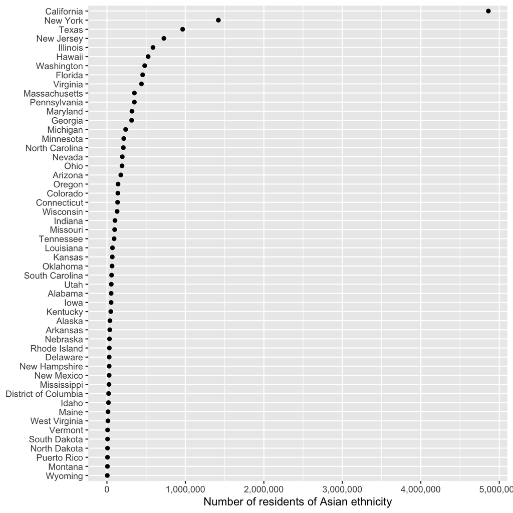

```r
ggplot(asia10, aes(x = reorder(NAME, value), y = value)) +
  geom_point() +
  scale_y_continuous(labels = scales::comma) +
  labs(
    x = NULL,
    y = "Number of residents of Asian ethnicity"
  ) +
  coord_flip()
```

This graph is a good start, but not entirely useful since it is based on the raw frequency of Asian individuals. California is at the top of the list, but it is also the most populous city. Instead, we could normalize this value as a percentage of the entire state population. To do that, we need to retrieve another variable:

```r
asia_pop <- get_decennial(
  geography = "state",
  variables = c("P008006", "P008001"),
  year = 2010
) %>%
  spread(variable, value) %>%
  mutate(pct_asia = P008006 / P008001)
```

```
## Using Census Summary File 1
```

```r
asia_pop
```

```
## # A tibble: 52 × 5
##    GEOID NAME                  P008001 P008006 pct_asia
##    <chr> <chr>                   <dbl>   <dbl>    <dbl>
##  1 01    Alabama               4779736   53595   0.0112
##  2 02    Alaska                 710231   38135   0.0537
##  3 04    Arizona               6392017  176695   0.0276
##  4 05    Arkansas              2915918   36102   0.0124
##  5 06    California           37253956 4861007   0.130
##  6 08    Colorado              5029196  139028   0.0276
##  7 09    Connecticut           3574097  135565   0.0379
##  8 10    Delaware               897934   28549   0.0318
##  9 11    District of Columbia   601723   21056   0.0350
## 10 12    Florida              18801310  454821   0.0242
## # ℹ 42 more rows
```

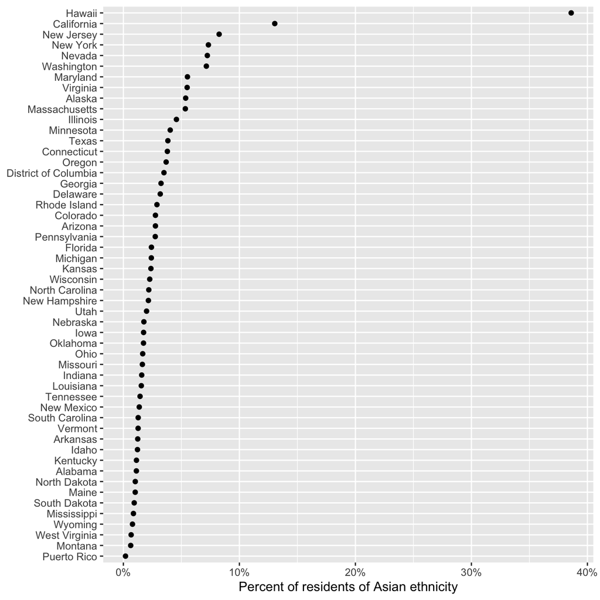

```r
ggplot(asia_pop, aes(x = reorder(NAME, pct_asia), y = pct_asia)) +
  geom_point() +
  scale_y_continuous(labels = scales::percent) +
  labs(
    x = NULL,
    y = "Percent of residents of Asian ethnicity"
  ) +
  coord_flip()
```

`get_acs()` retrieves data from the American Community Survey. This survey is administered to a sample of 3 million households on an annual basis, so the data points are estimates characterized by a margin of error. `tidycensus` returns both the original estimate and margin of error. Let’s get median household income data from the 2014-2019 ACS for each state.

```r
usa_inc <- get_acs(
  geography = "state",
  variables = c(medincome = "B19013_001"),
  year = 2019
)
usa_inc
```

```
## # A tibble: 52 × 5
##    GEOID NAME                 variable  estimate   moe
##    <chr> <chr>                <chr>        <dbl> <dbl>
##  1 01    Alabama              medincome    50536   304
##  2 02    Alaska               medincome    77640  1015
##  3 04    Arizona              medincome    58945   266
##  4 05    Arkansas             medincome    47597   328
##  5 06    California           medincome    75235   232
##  6 08    Colorado             medincome    72331   370
##  7 09    Connecticut          medincome    78444   553
##  8 10    Delaware             medincome    68287   696
##  9 11    District of Columbia medincome    86420  1008
## 10 12    Florida              medincome    55660   220
## # ℹ 42 more rows
```

Now we return both an `estimate` column for the ACS estimate and `moe` for the margin of error (defaults to 90% confidence interval).

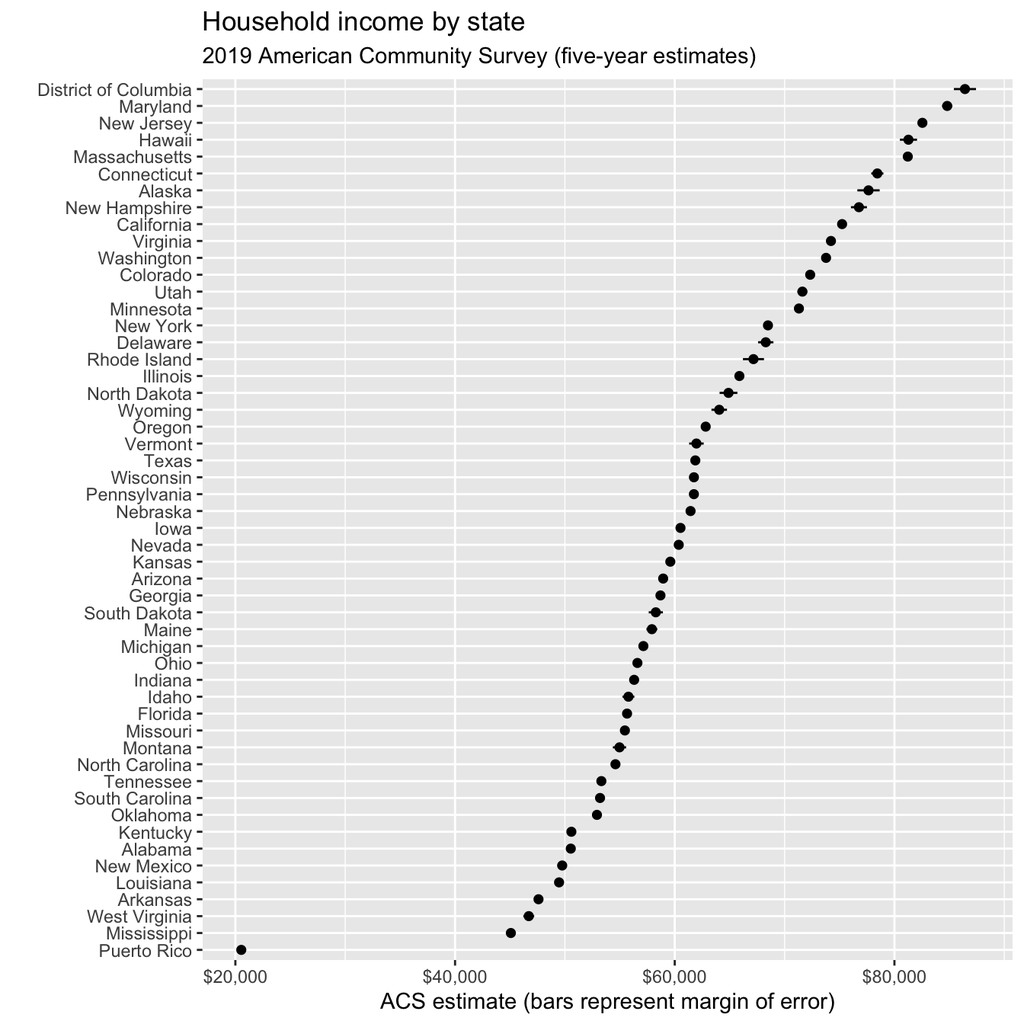

```r
usa_inc %>%
  ggplot(aes(x = reorder(NAME, estimate), y = estimate)) +
  geom_pointrange(aes(
    ymin = estimate - moe,
    ymax = estimate + moe
  ),
  size = .25
  ) +
  scale_y_continuous(labels = scales::dollar) +
  coord_flip() +
  labs(
    title = "Household income by state",
    subtitle = "2019 American Community Survey (five-year estimates)",
    x = "",
    y = "ACS estimate (bars represent margin of error)"
  )
```

### Search for variables

`get_acs()` or `get_decennial()` requires knowing the variable ID, of which there are thousands. `load_variables()` downloads a list of variable IDs and labels for a given Census or ACS and dataset. You can then use `View()` to interactively browse through and filter for variables in RStudio.

### Drawing maps

`tidycensus` also can return simple feature geometry for geographic units along with variables from the decennial Census or ACS, which can then be visualized using `geom_sf()`.. Let’s look at median household income by Census tracts from the 2014-2019 ACS in Polk County, Iowa:

```r
polk <- get_acs(
  state = "IA",
  county = "Polk",
  geography = "tract",
  variables = c(medincome = "B19013_001"),
  year = 2019,
  geometry = TRUE
)
```

```r
polk
```

```
## Simple feature collection with 98 features and 5 fields
## Geometry type: POLYGON
## Dimension:     XY
## Bounding box:  xmin: -93.81572 ymin: 41.48184 xmax: -93.32841 ymax: 41.86347
## Geodetic CRS:  NAD83
## First 10 features:
##          GEOID                                   NAME  variable estimate   moe
## 1  19153004602  Census Tract 46.02, Polk County, Iowa medincome    41985  8586
## 2  19153011701 Census Tract 117.01, Polk County, Iowa medincome   127923 14809
## 3  19153000400      Census Tract 4, Polk County, Iowa medincome    44238  6139
## 4  19153005000     Census Tract 50, Polk County, Iowa medincome    25806 11561
## 5  19153000801   Census Tract 8.01, Polk County, Iowa medincome    66694 11251
## 6  19153004900     Census Tract 49, Polk County, Iowa medincome    32161 19458
## 7  19153010407 Census Tract 104.07, Polk County, Iowa medincome   105385 14989
## 8  19153010404 Census Tract 104.04, Polk County, Iowa medincome    89081 13076
## 9  19153004004  Census Tract 40.04, Polk County, Iowa medincome    77922  5696
## 10 19153000202   Census Tract 2.02, Polk County, Iowa medincome    60000 10075
##                          geometry
## 1  POLYGON ((-93.62575 41.5409...
## 2  POLYGON ((-93.75592 41.6584...
## 3  POLYGON ((-93.62481 41.6367...
## 4  POLYGON ((-93.63846 41.6004...
## 5  POLYGON ((-93.70268 41.6366...
## 6  POLYGON ((-93.62581 41.6121...
## 7  POLYGON ((-93.75595 41.6439...
## 8  POLYGON ((-93.73649 41.6384...
## 9  POLYGON ((-93.70337 41.5556...
## 10 POLYGON ((-93.579 41.60539,...
```

This looks similar to the previous output but because we set `geometry = TRUE` it is now a simple features data frame with a `geometry` column defining the geographic feature. We can visualize it using `geom_sf()` and `viridis::scale_*_viridis()` to adjust the color palette.

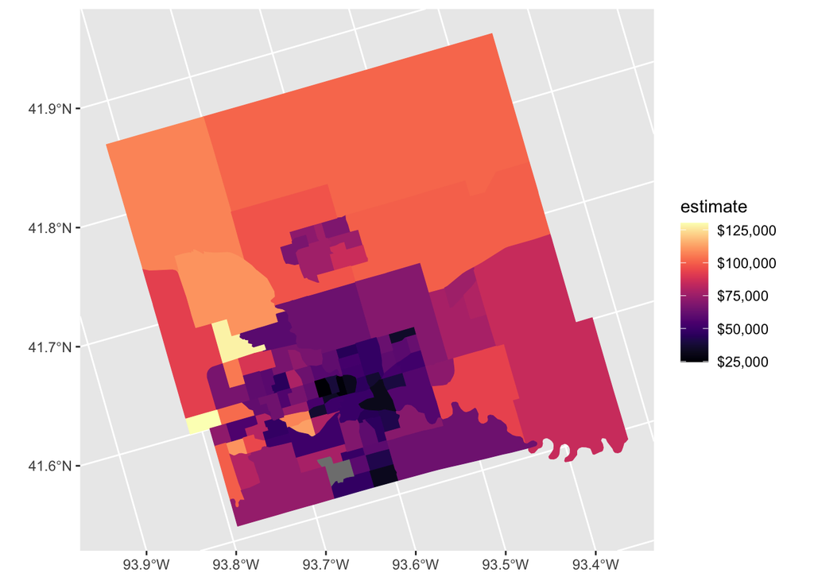

```r
ggplot(data = polk) +
  geom_sf(mapping = aes(fill = estimate, color = estimate)) +
  coord_sf(crs = 26911) +
  scale_fill_viridis(
    option = "magma",
    labels = scales::dollar,
    aesthetics = c("fill", "color")
  )
```

```r
write_csv(asia_pop, "../data/census_asia_pop.csv")
write_csv(asia10, "../data/census_asia10.csv")
write_csv(polk, "../data/census_polk.csv")
write_csv(usa_inc, "../data/census_usa_inc.csv")
```